# SSCECON207: The 2001 US crisis

Spring 2023 (June) Last updated: 2023-06-03

# Introduction

This case looks at the causes of the 2001 US recession. It explains how to find these causes, how to evaluate their relative importance, and how to measure their effects. This case is fairly straightforward: the economy largely follows the predictions of the IS-LM model; the causes, in hindsight, are clear. Still, we hope this case gives you a useful primer on how to understand more complex crises.

*Note:*  
*The code used to create the figures used in this case study is available on [Github](https://github.com/ucrdatacenter/projects/blob/main/SSCECON207/2023h1/US2001code.R).*

# Causes

We study two potential causes: declining business confidence and declining consumer confidence. The former originates from the burst of the so called dotcom bubble: the IS-LM model predicts that a fall in business confidence shifts the IS curve to the left and leads to lower investment and lower output. The latter originates from the fear and uncertainty caused by the September 11 terrorist attacks: the IS-LM model predicts that a fall in consumer confidence, shifts the IS curve to the left and leads to lower consumption and lower output. Let’s evaluate the importance of the two effects by studying the data.

## The IS curve

### Investment

Stock market indices provide a proxy for business confidence. If investors are optimistic about a firm’s future they are willing to pay a higher price for its shares. As a result, rising stock prices tend to indicate investor optimism. Since in this case we are particularly interested in stocks related to technology, we look at the NASDAQ composite stock index, which heavily features companies in information technology.

The evolution of the NASDAQ index shows that business confidence was growing in the ’90s but fell sharply in 2000-2001.

The IS-LM model predicts that this drop in business confidence should lead to a drop in investment. This is indeed what we see in 2000-2001. While the drop in personal investment is less drastic than the drop in business confidence, it is abrupt and substantial. It contrasts sharply with the period of continuous investment growth observed in the 90s. Thus, the data agrees with the theory.

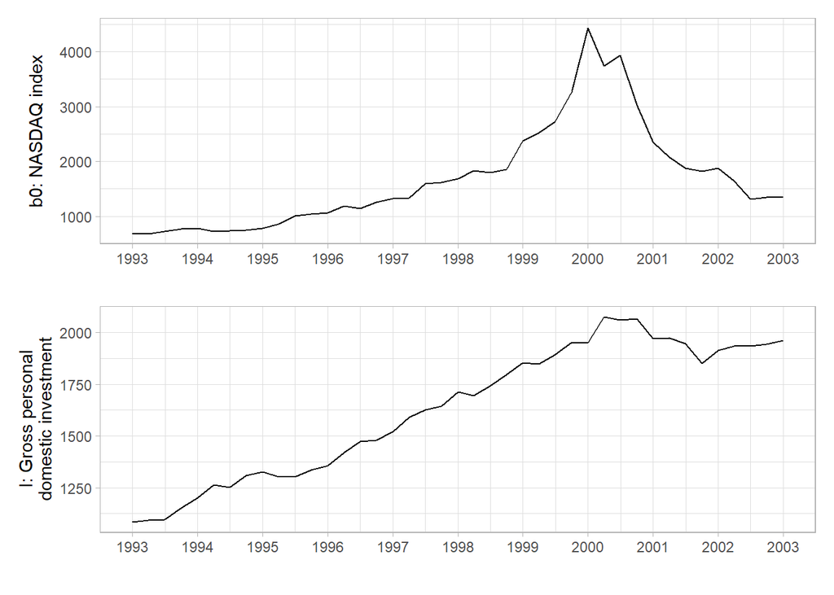

### Consumption

We plot the evolution of consumer confidence (measured by the Consumer sentiment indicator). This measure grew through the ’90s, stayed at high levels in 1998-2000, and dropped afterwards. In part, this drop was likely caused by the burst of the dotcom bubble and the emerging recession. In part, however, it was exogenous, caused by the September 11 terrorist attacks: at the time, experts expected the resulting fear and uncertainty to affect consumer behavior and to make the recession worse.

However, when we look at how consumption changed before and during the recession, we see only minor effects: in some quarters of 2001 consumption growth was close to zero but never negative; in other quarters it was positive and comparable to earlier years. Therefore, the drop in consumer confidence does not appear to have led to a drop in consumption, unlike what the IS-LM model predicts.

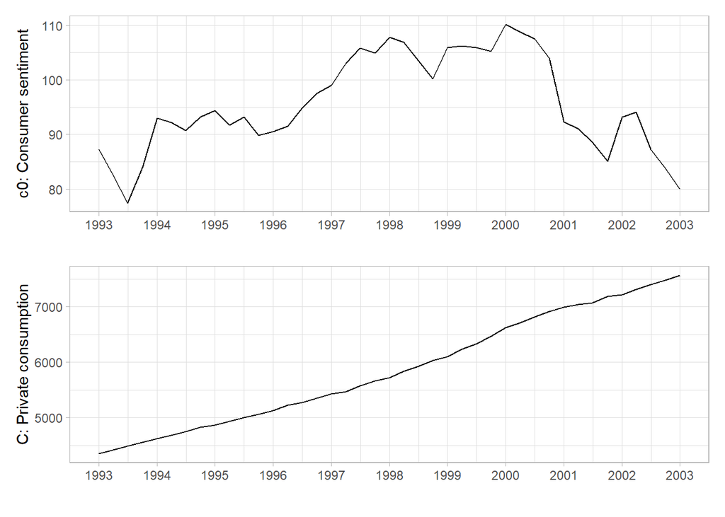

Overall, the IS curve appears to have shifted down during the recession, leading to a fall in output. The data suggests that this shift was mainly caused by the reduction in business confidence and the resulting fall in investment.

# Policy responses

During a recession policy-makers generally aim to return output back to its original level. Since in this case we have established that the recession was caused by a leftward shift of the IS-curve, the IS-LM model suggests that there are two potential policy responses: policy-makers can either shift the IS curve back to the right, or they can shift the LM curve down.

In the following we look at the data to determine what policy choices have been made.

## The IS curve

A government can shift the IS curve to the right by either increasing government expenditures or decreasing taxes. In this case the government appears to have done both. We see that government expenses decrease throughout the ’90s but start increasing from 2000 onward. This increase largely reflects extra defense and homeland security spending triggered by the terrorist attacks. Taxes (government receipts) increase at a steady pace in the ’90s, but drop sharply during the recession. In part, this drop is caused by the recession itself; in part, however, it reflects tax cuts introduced by the Bush administration as a measure to stimulate economic activity. You can also see how the two measures combine to transform budget surpluses of the late ’90s into deficits. So, the government appears to have actively used fiscal policy to fight the recession.

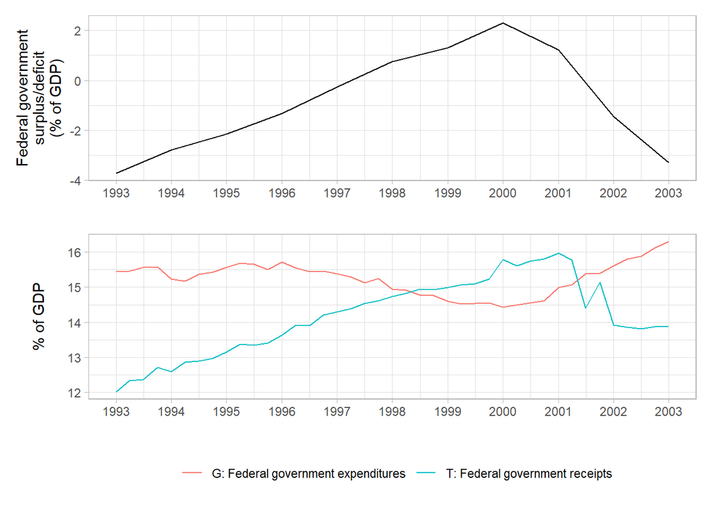

## The LM curve

Next to fiscal policy, policy-makers can also use monetary policy to increase output: the central bank (in this case the FED) can decrease interest rates thus shifting the LM curve down. The economy then moves along the IS curve to a higher level of output.

Plotting the U.S. federal funds rate shows that the FED indeed used this policy tool: they quickly lowered the interest rate from over 6% to around 2%.

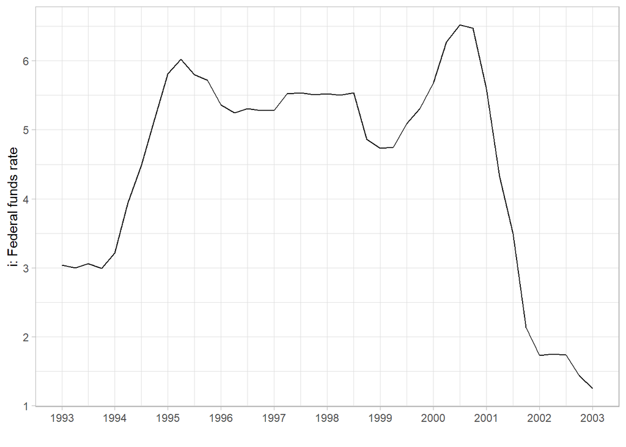

# Results

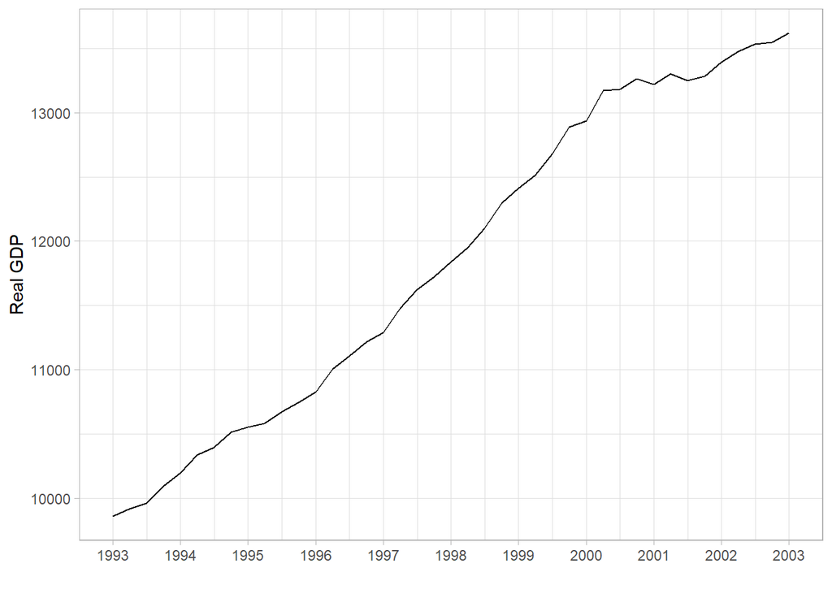